# CSCI E-63C: Final Exam

# Preface

For the final exam/project we will develop classification models using several approaches and compare their performance on a new dataset – so-called “Census Income” from UCI ML. It is available at UCI ML web site, but so that we are not at the mercy of UCI ML availability, there is also a local copy of it in our website in Canvas as a zip-archive of all associated files. Among other things, the description for this dataset also presents performance (prediction accuracy) observed by the dataset providers using variety of modeling techniques – this supplies a context for the errors of the models we will develop here.

Please note that the original data has been split up into training and test subsets, but there doesn’t seem to be anything particular about that split, so we might want to pool those two datasets together and split them into training and test as necessary ourselves. As you do that, please check that the attribute levels are consistent between those two files. For instance, the categorized income levels are indicated using slightly different notation in their training and test data. By now it should be quite straightforward for you to correct that when you pool them together.

Also, please note that there is non-negligible number of rows with missing values that for most analyses cannot be included without modification in the computation. Please decide how you want to handle them and proceed accordingly. The simplest and perfectly acceptable approach would be to exclude those observations from the rest of the analyses, but if you have time and inclination to investigate the impact of imputing them by various means, you are welcome to try.

Attribute called “final weight” in the dataset description represents demographic weighting of these observations. Please disregard it for the purposes of this assignment.

Additionally, several attributes in this dataset are categorical variables with more than two levels (e.g. native country, occupation, etc.). Please make sure to translate them into corresponding sets of dummy indicator variables for the methods that require such conversion (e.g. PCA) – R function `model.matrix` can be convenient for this, instead of generating those 0/1 indicators for each level of the factor manually (which is still perfectly fine). Some of those multi-level factors contain very sparsely populated categories – e.g. occupation “Armed-Forces” or work class “Never-worked” – it is your call whether you want to keep those observations in the data or exclude also on the basis that there is not enough data to adequately capture the impact of those categories. Feel free to experiment away!

Among the multi-level categorical attributes, native country attribute has the largest number of levels – several folds higher than any other attribute in this dataset – some of which have relatively few observations. This associated increase in dimensionality of the data may not be accompanied by a corresponding gain of resolution – e.g. would we expect this data to support the *difference* in income between descendants from Peru and Nicaragua, for example, or from Cambodia and Laos? Please feel free to evaluate the impact of inclusion and/or omission of this attribute in/from the model and/or discretizing it differently (e.g. US/non-US, etc.).

Lastly, the size of this dataset can make some of the modeling techniques run slower than what we were typically encountering in this class. You may find it helpful to do some of the exploration and model tuning on multiple random samples of smaller size as you decide on useful ranges of parameters/modeling choices, and then only perform a final run of fully debugged and working code on the full dataset.

# Problem 1: univariate and unsupervised analysis (20 points)

Download and read “Census Income” data into R and prepare graphical and numerical summaries of it: e.g. histograms of continuous attributes, contingency tables of categorical variables, scatterplots of continuous attributes with some of the categorical variables indicated by color/symbol shape, etc. Perform principal components analysis of this data (do you need to scale it prior to that? how would you represent multilevel categorical attributes to be used as inputs for PCA?) and plot observations in the space of the first few principal components with subjects’ gender and/or categorized income indicated by color/shape of the symbol. Perform univariate assessment of associations between outcome we will be modeling and each of the attributes (e.g. t-test or logistic regression for continuous attributes, contingency tables/Fisher exact test/$\chi^2$ test for categorical attributes). Summarize your observations from these assessments: does it appear that there is association between outcome and predictors? Which predictors seem to be more/less relevant?

```r
adult.train.original <- read.table("adult.data",sep=",",header=FALSE,quote="")
adult.test.original <- read.table("adult.test",sep=",",header=FALSE,quote="")
adult.test.original$V15 <- as.character(adult.test.original$V15)
adult.test.original$V15 <- substr(adult.test.original$V15, 1, nchar(adult.test.original$V15)-1)
adult <- rbind(adult.train.original, adult.test.original)
setDT(adult)
adult <- adult[V1!=' ?' & V2!=' ?' & V3!=' ?' & V4!=' ?' & V5!=' ?' & V6!=' ?' & V7!=' ?' & V8!=' ?' &
                 V9!=' ?' & V10!=' ?' & V11!=' ?' & V12!=' ?' & V13!=' ?' & V14!=' ?',]
colnames(adult) <- c("age","workclass","fnlwgt","education","education_num","marital_status","occupation","relationship","race","sex","capital_gain","capital_loss","hours_per_week","native_country","income")
adult <- adult[workclass != ' Without-pay' & education!=' Preschool' & occupation!=' Armed-Forces']
adult <- adult[native_country %in% c(' United-States',' Mexico', ' Philippines', ' South',' Puerto-Rico', ' England', ' Cuba', ' Canada', ' China', ' El-Salvador', ' India', ' India', ' Iran',
                                        ' Italy', ' Jamaica')]

adult[income==' >50K', income:='1']
adult[income==' <=50K', income:='0']
adult <- droplevels(adult)
adult$fnlwgt <- NULL
summary(adult)
```

```
##       age                    workclass             education
##  Min.   :17.00    Federal-gov     : 1364    HS-grad     :14373
##  1st Qu.:28.00    Local-gov       : 3036    Some-college: 9646
##  Median :37.00    Private         :32152    Bachelors   : 7350
##  Mean   :38.55    Self-emp-inc    : 1592    Masters     : 2430
##  3rd Qu.:47.00    Self-emp-not-inc: 3692    Assoc-voc   : 1900
##  Max.   :90.00    State-gov       : 1903    11th        : 1580
##                                            (Other)      : 6460
##  education_num                  marital_status             occupation
##  Min.   : 2.00    Divorced             : 6152    Prof-specialty : 5831
##  1st Qu.: 9.00    Married-AF-spouse    :   32    Exec-managerial: 5821
##  Median :10.00    Married-civ-spouse   :20385    Craft-repair   : 5812
##  Mean   :10.15    Married-spouse-absent:  480    Adm-clerical   : 5382
##  3rd Qu.:13.00    Never-married        :14098    Sales          : 5293
##  Max.   :16.00    Separated            : 1356    Other-service  : 4599
##                   Widowed              : 1236   (Other)         :11001
##           relationship                    race            sex
##   Husband       :18107    Amer-Indian-Eskimo:  430    Female:14188
##   Not-in-family :11328    Asian-Pac-Islander: 1002    Male  :29551
##   Other-relative: 1233    Black             : 4085
##   Own-child     : 6469    Other             :  287
##   Unmarried     : 4593    White             :37935
##   Wife          : 2009
##
##   capital_gain    capital_loss     hours_per_week         native_country
##  Min.   :    0   Min.   :   0.00   Min.   : 1.00    United-States:41238
##  1st Qu.:    0   1st Qu.:   0.00   1st Qu.:40.00    Mexico       :  875
##  Median :    0   Median :   0.00   Median :40.00    Philippines  :  280
##  Mean   : 1116   Mean   :  89.23   Mean   :40.96    Puerto-Rico  :  174
##  3rd Qu.:    0   3rd Qu.:   0.00   3rd Qu.:45.00    Canada       :  163
##  Max.   :99999   Max.   :4356.00   Max.   :99.00    India        :  146
##                                                    (Other)       :  863
##  income
##  1:10929
##  0:32810
##
##
##
##
##
```

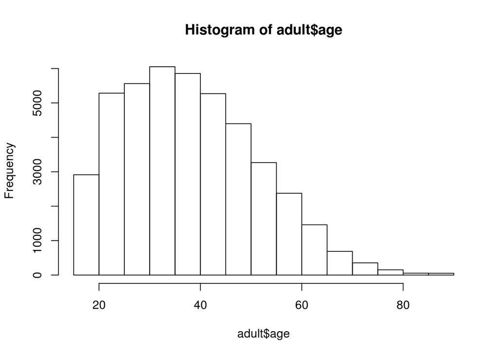

```r
hist(adult$age)
```

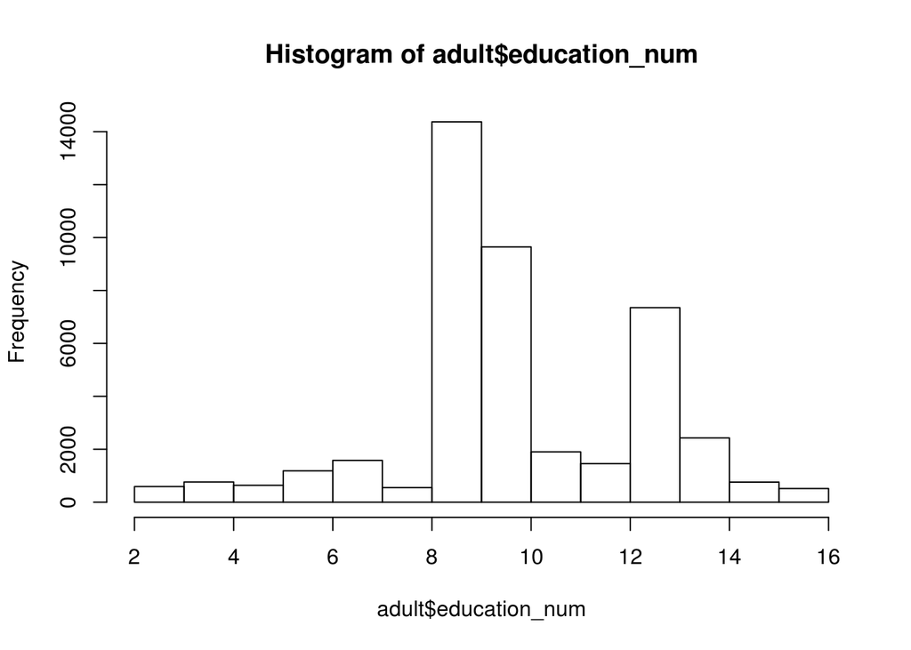

```r
hist(adult$education_num)
```

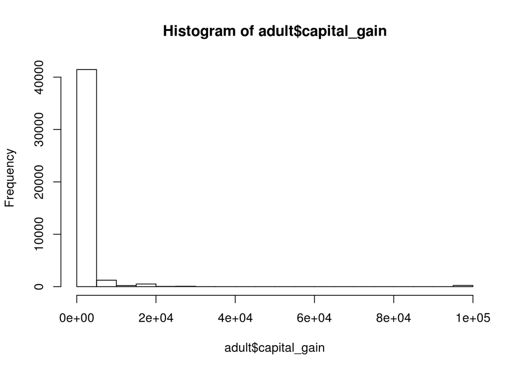

```r
hist(adult$capital_gain)
```

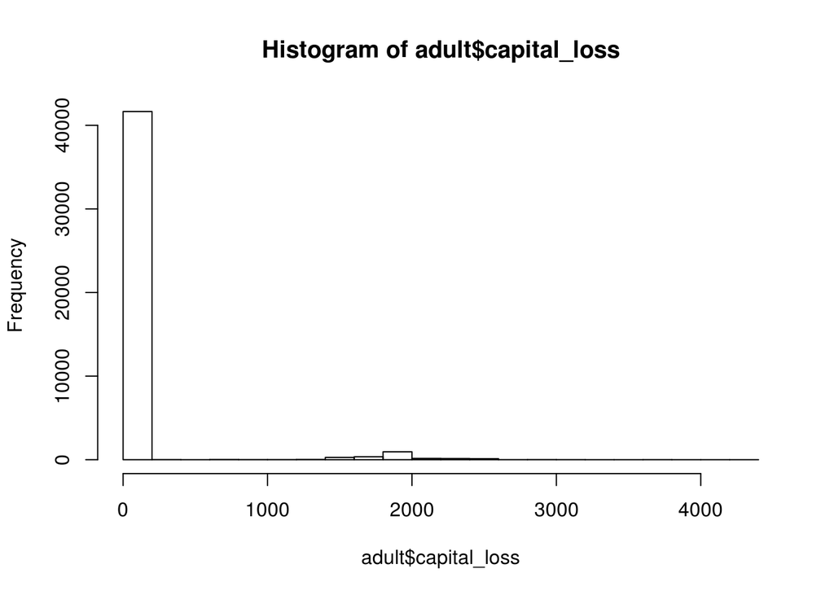

```r
hist(adult$capital_loss)
```

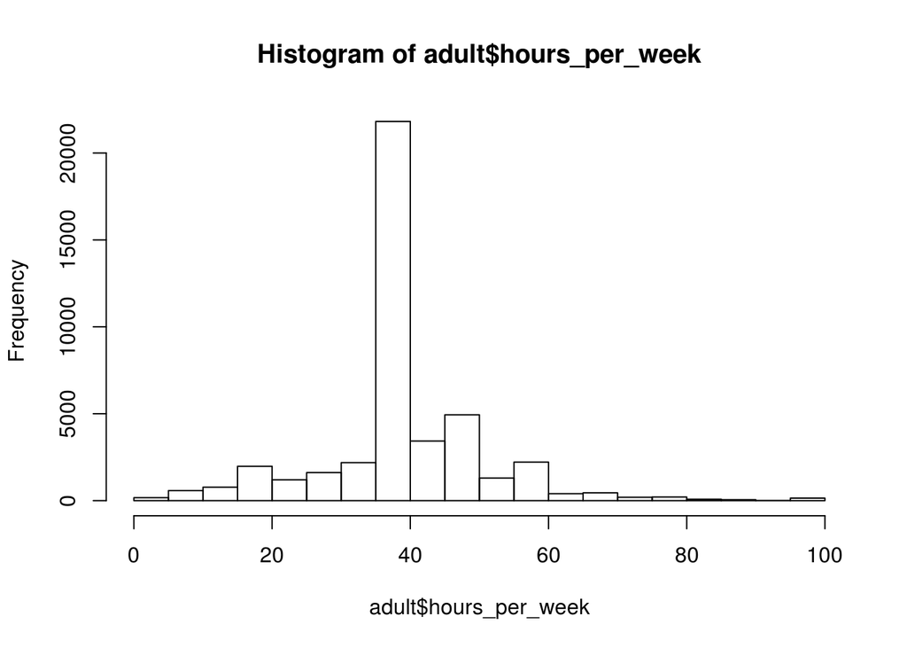

```r
hist(adult$hours_per_week)
```

```r
table(adult$workclass)
```

```
##
##       Federal-gov         Local-gov           Private      Self-emp-inc
##              1364              3036             32152              1592
##  Self-emp-not-inc         State-gov
##              3692              1903
```

```r
table(adult$education)
```

```
##
##          10th          11th          12th       1st-4th       5th-6th
##          1185          1580           550           184           406
##       7th-8th           9th    Assoc-acdm     Assoc-voc     Bachelors
##           764           639          1457          1900          7350
##     Doctorate       HS-grad       Masters   Prof-school  Some-college
##           515         14373          2430           760          9646
```

```r
table(adult$marital_status)
```

```
##
##               Divorced      Married-AF-spouse     Married-civ-spouse
##                   6152                     32                  20385
##  Married-spouse-absent          Never-married              Separated
##                    480                  14098                   1356
##                Widowed
##                   1236
```

```r
table(adult$occupation)
```

```
##
##       Adm-clerical       Craft-repair    Exec-managerial
##               5382               5812               5821
##    Farming-fishing  Handlers-cleaners  Machine-op-inspct
##               1432               1968               2796
##      Other-service    Priv-house-serv     Prof-specialty
##               4599                199               5831
##    Protective-serv              Sales       Tech-support
##                954               5293               1382
##   Transport-moving
##               2270
```

```r
table(adult$relationship)
```

```
##
##         Husband   Not-in-family  Other-relative       Own-child
##           18107           11328            1233            6469
##       Unmarried            Wife
##            4593            2009
```

```r
table(adult$race)
```

```
##
##  Amer-Indian-Eskimo  Asian-Pac-Islander               Black
##                 430                1002                4085
##               Other               White
##                 287               37935
```

```r
table(adult$sex)
```

```
##
##  Female    Male
##   14188   29551
```

```r
table(adult$native_country)
```

```
##
##         Canada          China           Cuba    El-Salvador        England
##            163            111            133            141            119
##          India           Iran          Italy        Jamaica         Mexico
##            146             56            100            102            875
##    Philippines    Puerto-Rico          South  United-States
##            280            174            101          41238
```

[output not shown]

[output cut: 127 more lines]

[output not shown]

[figure not shown]

```r
adult_modelmatrix <- model.matrix(income~., adult)
adult_modelmatrix_pca <- prcomp(adult_modelmatrix)
biplot(adult_modelmatrix_pca, pc.biplot = T, scale = 0)
```

```r
cor(y=as.numeric(adult$income),x=adult$age)
```

```
## [1] -0.2389065
```

```r
cor(y=as.numeric(adult$income),x=adult$education_num)
```

```
## [1] -0.3343476
```

```r
cor(y=as.numeric(adult$income),x=adult$capital_gain)
```

```
## [1] -0.2212589
```

```r
cor(y=as.numeric(adult$income),x=adult$capital_loss)
```

```
## [1] -0.1487749
```

```r
cor(y=as.numeric(adult$income),x=adult$hours_per_week)
```

```
## [1] -0.2271287
```

```r
chisq.test(y=adult$income, x=adult$workclass)
```

```
##
##  Pearson's Chi-squared test
##
## data:  adult$workclass and adult$income
## X-squared = 1146.8, df = 5, p-value < 2.2e-16
```

```r
chisq.test(y=adult$income, x=adult$education)
```

```
##
##  Pearson's Chi-squared test
##
## data:  adult$education and adult$income
## X-squared = 5772.2, df = 14, p-value < 2.2e-16
```

```r
chisq.test(y=adult$income, x=adult$marital_status)
```

```
##
##  Pearson's Chi-squared test
##
## data:  adult$marital_status and adult$income
## X-squared = 8876.3, df = 6, p-value < 2.2e-16
```

```r
chisq.test(y=adult$income, x=adult$occupation)
```

```
##
##  Pearson's Chi-squared test
##
## data:  adult$occupation and adult$income
## X-squared = 5197, df = 12, p-value < 2.2e-16
```

```r
chisq.test(y=adult$income, x=adult$relationship)
```

```
##
##  Pearson's Chi-squared test
##
## data:  adult$relationship and adult$income
## X-squared = 9117.5, df = 5, p-value < 2.2e-16
```

```r
chisq.test(y=adult$income, x=adult$race)
```

```
##
##  Pearson's Chi-squared test
##
## data:  adult$race and adult$income
## X-squared = 432.49, df = 4, p-value < 2.2e-16
```

```r
chisq.test(y=adult$income, x=adult$sex)
```

```
##
##  Pearson's Chi-squared test with Yates' continuity correction
##
## data:  adult$sex and adult$income
## X-squared = 2051, df = 1, p-value < 2.2e-16
```

```r
chisq.test(y=adult$income, x=adult$native_country)
```

```
##
##  Pearson's Chi-squared test
##
## data:  adult$native_country and adult$income
## X-squared = 296.74, df = 13, p-value < 2.2e-16
```

> Can’t do rescale, there are columns having 0 variance

# Problem 2: logistic regression (25 points)

Develop logistic regression model of the outcome as a function of multiple predictors in the model. Which variables are significantly associated with the outcome? Test model performance on multiple splits of data into training and test subsets, summarize it in terms of accuracy/error, sensitivity/specificity and compare to the performance of other methods reported in the dataset description.

```r
lr <- glm(income~., data=adult, family = "binomial")
summary(lr)
```

```
##
## Call:
## glm(formula = income ~ ., family = "binomial", data = adult)
##
## Deviance Residuals:
##     Min       1Q   Median       3Q      Max
## -3.6261   0.0129   0.1923   0.5163   5.0686
##
## Coefficients: (1 not defined because of singularities)
##                                        Estimate Std. Error z value
## (Intercept)                           6.817e+00  4.147e-01  16.439
## age                                  -2.471e-02  1.410e-03 -17.519
## workclass Local-gov                   6.455e-01  9.346e-02   6.906
## workclass Private                     4.859e-01  7.796e-02   6.232
## workclass Self-emp-inc                3.464e-01  1.026e-01   3.377
## workclass Self-emp-not-inc            1.021e+00  9.143e-02  11.171
## workclass State-gov                   7.825e-01  1.030e-01   7.596
## education 11th                       -7.119e-02  1.810e-01  -0.393
## education 12th                       -5.021e-01  2.302e-01  -2.181
## education 1st-4th                     6.613e-01  4.825e-01   1.371
## education 5th-6th                     4.918e-01  3.060e-01   1.607
## education 7th-8th                     4.664e-01  2.045e-01   2.281
## education 9th                         2.710e-01  2.277e-01   1.190
## education Assoc-acdm                 -1.428e+00  1.520e-01  -9.397
## education Assoc-voc                  -1.314e+00  1.467e-01  -8.959
## education Bachelors                  -1.990e+00  1.367e-01 -14.555
## education Doctorate                  -2.862e+00  1.873e-01 -15.283
## education HS-grad                    -8.603e-01  1.331e-01  -6.462
## education Masters                    -2.310e+00  1.453e-01 -15.903
## education Prof-school                -2.939e+00  1.762e-01 -16.678
## education Some-college               -1.214e+00  1.350e-01  -8.994
## education_num                                NA         NA      NA
## marital_status Married-AF-spouse     -2.616e+00  4.876e-01  -5.366
## marital_status Married-civ-spouse    -2.294e+00  2.309e-01  -9.935
## marital_status Married-spouse-absent -1.871e-01  1.942e-01  -0.964
## marital_status Never-married          4.230e-01  7.394e-02   5.721
## marital_status Separated              5.404e-02  1.376e-01   0.393
## marital_status Widowed               -1.091e-01  1.318e-01  -0.828
## occupation Craft-repair              -6.114e-02  6.630e-02  -0.922
## occupation Exec-managerial           -7.711e-01  6.388e-02 -12.071
```

[output cut: 98 more lines]

```
## native_country Mexico                5.44e-05 ***
## native_country Philippines           0.113666
## native_country Puerto-Rico           0.046080 *
## native_country South                 3.76e-06 ***
## native_country United-States         0.050634 .
## ---
## Signif. codes:  0 '***' 0.001 '**' 0.01 '*' 0.05 '.' 0.1 ' ' 1
##
## (Dispersion parameter for binomial family taken to be 1)
##
##     Null deviance: 49179  on 43738  degrees of freedom
## Residual deviance: 28497  on 43674  degrees of freedom
## AIC: 28627
##
## Number of Fisher Scoring iterations: 7
```

```r
resultDF <- data.frame()
for(i in 1:10){
  adult$randomNumber <- runif(nrow(adult))
  train <- adult[randomNumber<0.8,][,randomNumber:=NULL]
  test <- adult[randomNumber>=0.8,][,randomNumber:=NULL]
  adult$randomNumber <- NULL
  lr <- glm(income~., data=train, family = "binomial")
  test$prediction <- predict(lr, test, type="response")
  resultDF <- rbind(resultDF, data.frame("i"=i, "accuracy"=accuracy(test$income, test$prediction)))
}
resultDF
```

```
##     i accuracy.threshold accuracy.AUC accuracy.omission.rate
## 1   1                0.5    0.7653359              0.6005561
## 2   2                0.5    0.7644432              0.5998160
## 3   3                0.5    0.7711467              0.6176066
## 4   4                0.5    0.7598967              0.5903942
## 5   5                0.5    0.7618808              0.6014330
## 6   6                0.5    0.7584928              0.5906618
## 7   7                0.5    0.7592264              0.5985015
## 8   8                0.5    0.7678130              0.6101545
## 9   9                0.5    0.7663911              0.6093458
## 10 10                0.5    0.7613268              0.5976004
##    accuracy.sensitivity accuracy.specificity accuracy.prop.correct
## 1             0.3994439           0.06988429             0.1513867
## 2             0.4001840           0.07092969             0.1539979
## 3             0.3823934           0.07531317             0.1520568
```

[output cut: 18 more lines]

> The variables with 3 *’s are significant variables

> With multiple splits, the error rate is much higher compared to other methods.

# Problem 3: random forest (25 points)

Develop random forest model of the categorized income. Present variable importance plots and comment on relative importance of different attributes in the model. Did attributes showing up as more important in random forest model also appear as significantly associated with the outcome by logistic regression? Test model performance on multiple splits of data into training and test subsets, compare test and out-of-bag error estimates, summarize model performance in terms of accuracy/error, sensitivity/specificity and compare to the performance of other methods reported in the dataset description.

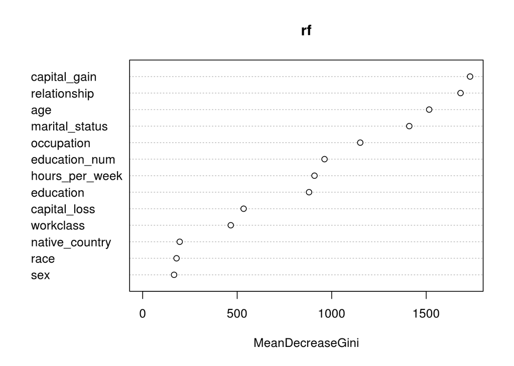

```r
rf <- randomForest(income~., data=adult)
varImpPlot(rf)
```

```r
resultDF <- data.frame()
for(i in 1:10){
  adult$randomNumber <- runif(nrow(adult))
  train <- adult[randomNumber<0.8,][,randomNumber:=NULL]
  test <- adult[randomNumber>=0.8,][,randomNumber:=NULL]
  adult$randomNumber <- NULL
  rf <- randomForest(income~., data=train)
  test$prediction <- predict(rf, test)
  resultDF <- rbind(resultDF, data.frame("i"=i, "accuracy"=accuracy(test$income, test$prediction)))
}
resultDF
```

```
##     i accuracy.threshold accuracy.AUC accuracy.omission.rate
## 1   1                0.5    0.7820216              0.3727811
## 2   2                0.5    0.7787116              0.3755782
## 3   3                0.5    0.7892473              0.3548387
## 4   4                0.5    0.7810889              0.3764548
## 5   5                0.5    0.7866922              0.3646308
## 6   6                0.5    0.7895934              0.3553459
## 7   7                0.5    0.7877356              0.3587056
## 8   8                0.5    0.7875758              0.3606185
## 9   9                0.5    0.7861922              0.3632120
## 10 10                0.5    0.7873717              0.3682310
##    accuracy.sensitivity accuracy.specificity accuracy.prop.correct
## 1             0.6272189            0.9368242             0.8583785
## 2             0.6244218            0.9330014             0.8570941
## 3             0.6451613            0.9333333             0.8615385
```

[output cut: 18 more lines]

> The important variables in random forest are also those important for logistic regression

> The error rate is at lower level compared to other methods

# Problem 4: SVM (25 points)

Develop SVM model of this data choosing parameters (e.g. choice of kernel, cost, etc.) that appear to yield better performance. Test model performance on multiple splits of data into training and test subsets, summarize model performance in terms of accuracy/error, sensitivity/specificity and compare to the performance of other methods reported in the dataset description.

# Problem 5: compare logistic regression, random forest and SVM model performance (5 points)

Compare performance of the models developed above (logistic regression, random forest, SVM) in terms of their accuracy, error and sensitivity/specificity. Comment on differences and similarities between them.

# Extra 10 points: KNN model

Develop KNN model for this data, evaluate its performance for different values of $k$ on different splits of the data into training and test and compare it to the performance of other methods reported in the dataset description. Notice that this dataset includes many categorical variables as well as continuous attributes measured on different scales, so that the distance has to be defined to be meaningful (probably avoiding subtraction of the numerical values of multi-level factors directly or adding differences between untransformed age and capital gain/loss attributes).

# Extra 15 points: variable importance in SVM

SVM does not appear to provide readily available tools for judging relative importance of different attributes in the model. Please evaluate here an approach similar to that employed by random forest where importance of any given attribute is measured by the decrease in model performance upon randomization of the values for this attribute.